# notebook_2_tests-conditions-adverses

```python
!pip install openml
!pip install -U albumentations
!pip install optuna-integration[tfkeras]
!pip install visualkeras
```

[output not shown]

```python
%matplotlib inline
import numpy as np
import pandas as pd
import math
import matplotlib.pyplot as plt
import seaborn as sns
import matplotlib.image as mpimg
import random
import json
import os
import gc

import optuna
from optuna.integration import TFKerasPruningCallback
import openml as oml
from collections import Counter
import cv2

# Scikit-learn
from sklearn.model_selection import train_test_split
from sklearn.metrics import (classification_report, precision_score, recall_score,
                             f1_score, confusion_matrix, roc_auc_score,
                             average_precision_score, precision_recall_curve, auc)

# Albumentations pour l'augmentation d'images
import albumentations as A

# TensorFlow et Keras
import tensorflow as tf
from tensorflow import keras
from tensorflow.keras import Model, callbacks
from tensorflow.keras.models import Sequential, save_model, load_model
from tensorflow.keras.layers import (Input, Conv2D, MaxPooling2D, Flatten, Dense, Dropout,
                                     BatchNormalization, Add, ReLU, GlobalAveragePooling2D,
                                     UpSampling2D)
from tensorflow.keras.optimizers import Adam, Adagrad
from tensorflow.keras.callbacks import EarlyStopping, ReduceLROnPlateau
from tensorflow.keras.utils import to_categorical
from tensorflow.keras.initializers import HeNormal
from tensorflow.keras.applications import ResNet50

from keras.utils import plot_model
import visualkeras

from IPython.display import clear_output
```

## 8. **Conditions adverses**

Dans cette section, la robustesse des modèles développés est évaluée dans des conditions adverses.  
Il est crucial de comprendre comment les modèles réagissent face à des scénarios où les données peuvent être corrompues, incomplètes, ou affectées par du bruit, car ces situations reflètent des défis du monde réel. Tester les modèles dans ces conditions permet de juger leur capacité à généraliser et à maintenir une performance acceptable lorsqu'ils sont confrontés à des variations inattendues dans les données d'entrée.

### 8.1 **Robustesse au bruit dans les données**

#### 8.1.1 Preprocessing

```python
metabase = pd.read_csv('/kaggle/input/gtsrb-german-traffic-sign/Meta.csv')
```

```python
data = pd.read_csv('/kaggle/input/gtsrb-german-traffic-sign/Test.csv')
merged_data = data.merge(metabase[['ClassId', 'ShapeId', 'ColorId']], on='ClassId', how='left')

def load_and_preprocess_images(metadata, target_size=(64, 64)):
    images = []
    labels = []

    for index, row in metadata.iterrows():
        img_path = f"/kaggle/input/gtsrb-german-traffic-sign/{row['Path']}"
        class_id = row['ClassId']

        img = cv2.imread(img_path)

        if img is None:
            print(f"Erreur de chargement de l'image à {img_path}")
            continue

        img = cv2.cvtColor(img, cv2.COLOR_BGR2RGB)
        img = cv2.resize(img, target_size)          # Redimensionnement

        images.append(img)
        labels.append(class_id)

    return np.array(images), np.array(labels)

X, y = load_and_preprocess_images(merged_data)

print(f"Nombre d'images chargées: {X.shape[0]}")
print(f"Dimensions de chaque image: {X.shape[1:]}")
print(f"Nombre d'étiquettes: {y.shape[0]}")
print(f"Valeurs min et max de X: {X.min()}, {X.max()}")
```

```
Nombre d'images chargées: 12630
Dimensions de chaque image: (64, 64, 3)
Nombre d'étiquettes: 12630
Valeurs min et max de X: 0, 255
```

#### 8.1.2 Datasplit

```python
# Stratification multiple (couleur, forme, classe)
merged_data['Stratifier'] = merged_data['ClassId'].astype(str) + '_' + merged_data['ShapeId'].astype(str) + '_' + merged_data['ColorId'].astype(str)

# Datasplit
X_train, X_temp, y_train, y_temp = train_test_split(X, merged_data['Stratifier'], test_size=0.30, random_state=42, stratify=merged_data['Stratifier'])
X_val, X_test, y_val, y_test = train_test_split(X_temp, y_temp, test_size=0.50, random_state=42, stratify=y_temp)

# Extraction de ClassId
y_train = [label.split('_')[0] for label in y_train]
y_val = [label.split('_')[0] for label in y_val]
y_test = [label.split('_')[0] for label in y_test]

print("Shapes des datasets après division :")
print(f"\nX_train shape: {X_train.shape}, y_train shape: {np.array(y_train).shape}")
print(f"X_val shape: {X_val.shape}, y_val shape: {np.array(y_val).shape}")
print(f"X_test shape: {X_test.shape}, y_test shape: {np.array(y_test).shape}")

print("\nNombre de classes uniques dans y_train :", len(np.unique(y_train)))
print("Nombre de classes uniques dans y_val :", len(np.unique(y_val)))
print("Nombre de classes uniques dans y_test :", len(np.unique(y_test)))
```

```
Shapes des datasets après division :

X_train shape: (8841, 64, 64, 3), y_train shape: (8841,)
X_val shape: (1894, 64, 64, 3), y_val shape: (1894,)
X_test shape: (1895, 64, 64, 3), y_test shape: (1895,)

Nombre de classes uniques dans y_train : 43
Nombre de classes uniques dans y_val : 43
Nombre de classes uniques dans y_test : 43
```

```python
gc.collect()
```

```
98
```

```python
def display_images(originals, augmented, num_augmentations=5):
    plt.figure(figsize=(15, 12))

    num_examples = len(originals)

    for idx in range(num_examples):

        plt.subplot(num_examples, num_augmentations + 1, idx * (num_augmentations + 1) + 1)           # original
        plt.imshow(originals[idx])
        plt.title(f'Original {idx + 1}')
        plt.axis('off')

        for i in range(num_augmentations):
            plt.subplot(num_examples, num_augmentations + 1, idx * (num_augmentations + 1) + i + 2)   # augmented
            plt.imshow(augmented[idx * num_augmentations + i])
            plt.title(f'Augmentée {i + 1}')
            plt.axis('off')

    plt.tight_layout()
    plt.show()
```

#### 8.1.3 Augmentation des images : fonctions utilisées

1. **`add_gaussian_noise(image)`** :
   - Ajoute du bruit gaussien à l'image. Le bruit est généré selon une distribution normale avec une moyenne de 0 et un écart-type de 25.
   - L'image bruitée est ensuite recadrée (grâce à `np.clip`) pour s'assurer que les valeurs des pixels restent dans la plage [0, 255].
2. **`random_occlusion(image, max_occlusion_size=(32, 32))`** :
   - Applique une occlusion aléatoire à une partie de l'image.
   - Une région rectangulaire de dimensions aléatoires (jusqu'à 32x32 pixels par défaut soit 50%) est sélectionnée et remplie de noir (valeur 0).
3. **`color_shift(image)`** :
   - Modifie les canaux de couleur de l'image. Un décalage aléatoire compris entre -15 et 15 est appliqué indépendamment à chaque canal de couleur (R, G, B), rendant l'image moins reconnaissable tout en conservant ses structures globales.
4. **`motion_blur(image)`** :
   - Applique un flou de mouvement à l'image en utilisant un noyau de convolution de taille 10.
   - Le noyau est configuré pour simuler un flou directionnel, et la fonction `cv2.filter2D` est utilisée pour filtrer l'image avec ce noyau.
5. **`augment_images(images, num_augmentations=5)`** :
   - Génère des versions augmentées de chaque image.
   - Pour chaque image, cinq transformations aléatoires sont appliquées parmi les transformations définies (bruit gaussien, occlusion, décalage de couleur et flou de mouvement).

```
Shape des X_train avant augmentation : (8841, 64, 64, 3)
Shape des y_train avant duplication : 8841
Shape des X_val avant augmentation : (1894, 64, 64, 3)
Shape des y_val avant duplication : 1894
Shape des X_test avant augmentation : (1895, 64, 64, 3)
Shape des y_test avant duplication : 1895
Shape des X_train augmentés : (44205, 64, 64, 3)
Shape des y_train augmentés : (44205,)
Shape des X_val augmentés : (9470, 64, 64, 3)
Shape des y_val augmentés : (9470,)
Shape des X_test augmentés : (9475, 64, 64, 3)
Shape des y_test augmentés : (9475,)
TRAIN______
```

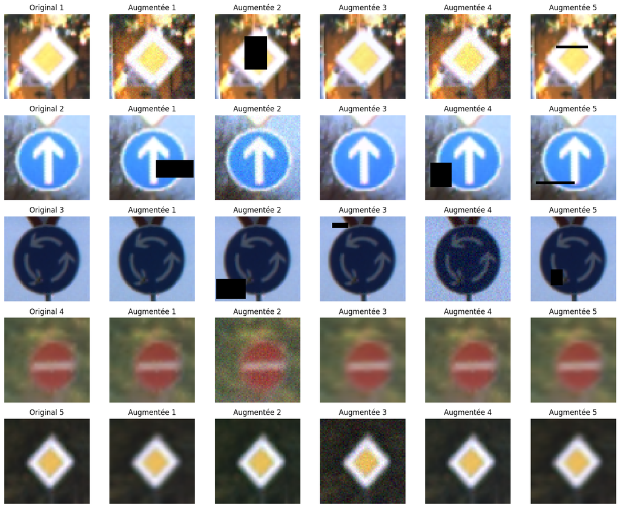

```
VALIDATION______
```

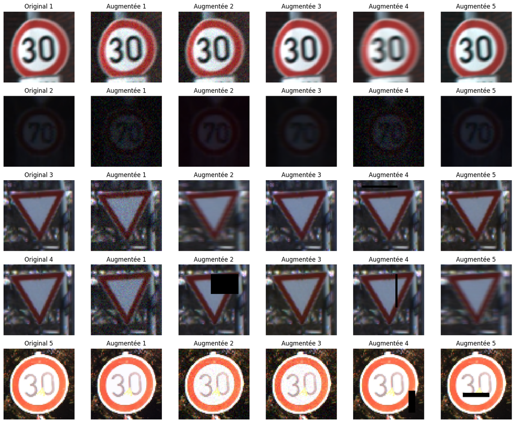

```
TEST______
```

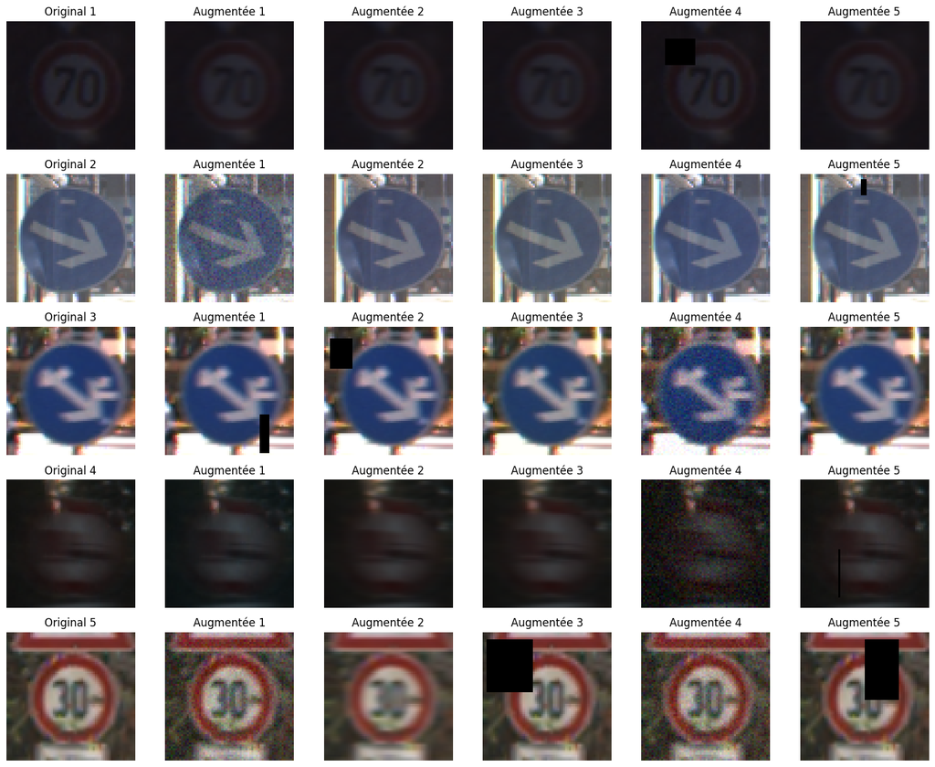

```python
def add_gaussian_noise(image):
    noise = np.random.normal(0, 25, image.shape)
    noisy_image = np.clip(image + noise, 0, 255).astype(np.uint8)
    return noisy_image

def random_occlusion(image, max_occlusion_size=(32, 32)):
    """
    Simule des occlusions en masquant une partie de l'image.
    """
    h, w, _ = image.shape
    max_height, max_width = max_occlusion_size
    max_height = min(max_height, h)
    max_width = min(max_width, w)
    occlusion_height = np.random.randint(1, max_height + 1)
    occlusion_width = np.random.randint(1, max_width + 1)
    y_start = np.random.randint(0, h - occlusion_height + 1)
    x_start = np.random.randint(0, w - occlusion_width + 1)
    image[y_start:y_start + occlusion_height, x_start:x_start + occlusion_width] = 0
    return image

def color_shift(image):
    """
    Modifie les canaux de couleur pour rendre l'image moins reconnaissable.
    """
    shift = np.random.uniform(-15, 15, size=image.shape[2])
    return np.clip(image + shift, 0, 255).astype(np.uint8)

def motion_blur(image):
    """
    Applique un flou de mouvement plus important à l'image.
    """
    kernel_size = 10
    kernel = np.zeros((kernel_size, kernel_size))
    kernel[int(kernel_size / 2), :] = np.ones(kernel_size)
    kernel = kernel / kernel_size
    return cv2.filter2D(image, -1, kernel)

def augment_images(images, num_augmentations=5):
    augmented_images = []

    transformations = [add_gaussian_noise, random_occlusion, color_shift, motion_blur]

    for image in images:
        for _ in range(num_augmentations):
            transform = random.choice(transformations)
            augmented_image = transform(np.copy(image))
            augmented_images.append(augmented_image)

    return np.array(augmented_images)

def duplicate_labels(labels, num_augmentations=5):
    """Duplique chaque label autant de fois que le nombre d'augmentations (pour y)"""
    return np.repeat(labels, num_augmentations)

nb_augm_per_image = 5  # Nombre d'augmentations par image

print("Shape des X_train avant augmentation :", X_train.shape)  # Vérifier la taille en entrée
print("Shape des y_train avant duplication :", len(y_train))
print("Shape des X_val avant augmentation :", X_val.shape)
print("Shape des y_val avant duplication :", len(y_val))
print("Shape des X_test avant augmentation :", X_test.shape)
print("Shape des y_test avant duplication :", len(y_test))

augmented_X_train = augment_images(X_train, num_augmentations=nb_augm_per_image)
augmented_y_train = duplicate_labels(y_train, num_augmentations=nb_augm_per_image)

augmented_X_val = augment_images(X_val, num_augmentations=nb_augm_per_image)
augmented_y_val = duplicate_labels(y_val, num_augmentations=nb_augm_per_image)

augmented_X_test = augment_images(X_test, num_augmentations=nb_augm_per_image)
augmented_y_test = duplicate_labels(y_test, num_augmentations=nb_augm_per_image)

print("Shape des X_train augmentés :", augmented_X_train.shape)  # Vérifier la taille en sortie
print("Shape des y_train augmentés :", augmented_y_train.shape)
print("Shape des X_val augmentés :", augmented_X_val.shape)
print("Shape des y_val augmentés :", augmented_y_val.shape)
print("Shape des X_test augmentés :", augmented_X_test.shape)
print("Shape des y_test augmentés :", augmented_y_test.shape)

# Afficher les images augmentées
print("TRAIN______")
display_images(X_train[:5], augmented_X_train[:5 * nb_augm_per_image], num_augmentations=nb_augm_per_image)
print("\nVALIDATION______")
display_images(X_val[:5], augmented_X_val[:5 * nb_augm_per_image], num_augmentations=nb_augm_per_image)
print("\nTEST______")
display_images(X_test[:5], augmented_X_test[:5 * nb_augm_per_image], num_augmentations=nb_augm_per_image)
```